# Strings and Factors

2023-10-10

## Strings and manipulations

```r
string_vec = c("my", "name", "is", "jeff")

str_detect(string_vec, "jeff")
```

```
## [1] FALSE FALSE FALSE  TRUE
```

^ `str_detect`, you want to use to find something that exists. use in conjunction with `filter` to get rid of things that don’t have a specific pattern match

```r
str_replace(string_vec, "jeff", "Jeff")
```

```
## [1] "my"   "name" "is"   "Jeff"
```

^ `str_replace` replaces characters in string vectors

```r
string_vec = c(
  "i think we all rule for participating",
  "i think i have been caught",
  "i think this will be quite fun actually",
  "it will be fun, i think"
  )

str_detect(string_vec, "i think")
```

```
## [1] TRUE TRUE TRUE TRUE
```

```r
str_detect(string_vec, "^i think")
```

```
## [1]  TRUE  TRUE  TRUE FALSE
```

```r
str_detect(string_vec, "i think$")
```

```
## [1] FALSE FALSE FALSE  TRUE
```

^ use `^` to indicate the line starts there, to indicate the first three rather than in the entire sentence. `$` does the opposite, for the end of the sentence

```r
string_vec = c(
  "Time for a Pumpkin Spice Latte!",
  "went to the #pumpkinpatch last weekend",
  "Pumpkin Pie is obviously the best pie",
  "SMASHING PUMPKINS -- LIVE IN CONCERT!!"
  )

str_detect(string_vec,"Pumpkin")
```

```
## [1]  TRUE FALSE  TRUE FALSE
```

```r
str_detect(string_vec,"pumpkin")
```

```
## [1] FALSE  TRUE FALSE FALSE
```

```r
str_detect(string_vec,"[Pp]umpkin")
```

```
## [1]  TRUE  TRUE  TRUE FALSE
```

^`[]` indicates that you can match one thing or the other thing (both? only one or the other?)

```r
string_vec = c(
  '7th inning stretch',
  '1st half soon to begin. Texas won the toss.',
  'she is 5 feet 4 inches tall',
  '3AM - cant sleep :('
  )

str_detect(string_vec, "[0-9]")
```

```
## [1] TRUE TRUE TRUE TRUE
```

```r
str_detect(string_vec, "^[0-9]")
```

```
## [1]  TRUE  TRUE FALSE  TRUE
```

```r
str_detect(string_vec, "^[0-9][a-zA-Z]")
```

```
## [1]  TRUE  TRUE FALSE  TRUE
```

^`[]` any instance that matches any number 0-9, add `^` to indicate first line, can layer `[]` to build

```r
string_vec = c(
  'Its 7:11 in the evening',
  'want to go to 7-11?',
  'my flight is AA711',
  'NetBios: scanning ip 203.167.114.66'
  )

str_detect(string_vec, "7.11")
```

```
## [1]  TRUE  TRUE FALSE  TRUE
```

^ `.` selects anything from the selected choices (eg “7, 11”)

```r
string_vec = c(
  'The CI is [2, 5]',
  ':-]',
  ':-[',
  'I found the answer on pages [6-7]'
  )

str_detect(string_vec, "\\[")
```

```
## [1]  TRUE FALSE  TRUE  TRUE
```

```r
str_detect(string_vec, "\\[[0-9]")
```

```
## [1]  TRUE FALSE FALSE  TRUE
```

^ in order to detect “[”, it tyipcally gets interpreted as a regular expression function. “[” is a special character and needs to be designated by “\”. (“" is also a special character, so add another one)

## Factors

this is a string variable:

```r
vec_sex = c("male", "male", "female", "female")

vec_sex
```

```
## [1] "male"   "male"   "female" "female"
```

this converts to a factor:

```r
vec_sex = factor(c("male", "male", "female", "female"))

vec_sex
```

```
## [1] male   male   female female
## Levels: female male
```

```r
as.numeric(vec_sex)
```

```
## [1] 2 2 1 1
```

```r
vec_sex = fct_relevel(vec_sex, "male")

vec_sex
```

```
## [1] male   male   female female
## Levels: male female
```

```r
as.numeric(vec_sex)
```

```
## [1] 1 1 2 2
```

^ indicates that there are two levels, automatically done from a string -> factor conversion. add on `as.numeric` to confirm factor numeric levels. use `fct_relevel` to change the order - since `factor` does alphabetically by default.

^ in general, overwhelming preference is for categorical variables, don’t label as “1”, “2”… becaues this can get very confusing. use actual, explicit labels so that when you convert to .csv, everyone knows what’s happening. use `forcats::` package to do the things you want to do.

## National Survey on Drug Use and Health (NSDUH) example

Reload data from `reading in data from web`.

```r
nsduh_url = "http://samhda.s3-us-gov-west-1.amazonaws.com/s3fs-public/field-uploads/2k15StateFiles/NSDUHsaeShortTermCHG2015.htm"

table_marj =
  read_html(nsduh_url) |>
  html_table() |>
  first() |>
  slice(-1)

table_marj
```

```
## # A tibble: 56 × 16
##    State     `12+(2013-2014)` `12+(2014-2015)` `12+(P Value)` `12-17(2013-2014)`
##    <chr>     <chr>            <chr>            <chr>          <chr>
##  1 Total U.… 12.90a           13.36            0.002          13.28b
##  2 Northeast 13.88a           14.66            0.005          13.98
##  3 Midwest   12.40b           12.76            0.082          12.45
##  4 South     11.24a           11.64            0.029          12.02
##  5 West      15.27            15.62            0.262          15.53a
##  6 Alabama   9.98             9.60             0.426          9.90
##  7 Alaska    19.60a           21.92            0.010          17.30
##  8 Arizona   13.69            13.12            0.364          15.12
##  9 Arkansas  11.37            11.59            0.678          12.79
## 10 Californ… 14.49            15.25            0.103          15.03
## # ℹ 46 more rows
## # ℹ 11 more variables: `12-17(2014-2015)` <chr>, `12-17(P Value)` <chr>,
## #   `18-25(2013-2014)` <chr>, `18-25(2014-2015)` <chr>, `18-25(P Value)` <chr>,
## #   `26+(2013-2014)` <chr>, `26+(2014-2015)` <chr>, `26+(P Value)` <chr>,
## #   `18+(2013-2014)` <chr>, `18+(2014-2015)` <chr>, `18+(P Value)` <chr>
```

^ this is not a tidy dataset: the columns that contain P values are fundamentally different from the others - they’re different? and strange - let’s exclude those. Second, age range is a variable and not a column name. There are also two separate variables encoded in column names. Lastly, some values have “a” at the end, which is not usable.

Clean and tidy the data.

```r
marj_df =
  table_marj |>
  select(-contains("P Value")) |>
  pivot_longer(
    -State,
    names_to = "age_year",
    values_to = "percent"
  )

marj_df
```

```
## # A tibble: 560 × 3
##    State      age_year         percent
##    <chr>      <chr>            <chr>
##  1 Total U.S. 12+(2013-2014)   12.90a
##  2 Total U.S. 12+(2014-2015)   13.36
##  3 Total U.S. 12-17(2013-2014) 13.28b
##  4 Total U.S. 12-17(2014-2015) 12.86
##  5 Total U.S. 18-25(2013-2014) 31.78
##  6 Total U.S. 18-25(2014-2015) 32.07
##  7 Total U.S. 26+(2013-2014)   9.63a
##  8 Total U.S. 26+(2014-2015)   10.25
##  9 Total U.S. 18+(2013-2014)   12.87a
## 10 Total U.S. 18+(2014-2015)   13.41
## # ℹ 550 more rows
```

we’re getting somewhere - now we have to separate `age_year`

```r
marj_df =
  table_marj |>
  select(-contains("P Value")) |>
  pivot_longer(
    -State,
    names_to = "age_year",
    values_to = "percent") |>
  separate(age_year, into = c("age", "year"), "\\(") |>
  mutate(year = str_replace(year, "\\)", ""))

marj_df
```

```
## # A tibble: 560 × 4
##    State      age   year      percent
##    <chr>      <chr> <chr>     <chr>
##  1 Total U.S. 12+   2013-2014 12.90a
##  2 Total U.S. 12+   2014-2015 13.36
##  3 Total U.S. 12-17 2013-2014 13.28b
##  4 Total U.S. 12-17 2014-2015 12.86
##  5 Total U.S. 18-25 2013-2014 31.78
##  6 Total U.S. 18-25 2014-2015 32.07
##  7 Total U.S. 26+   2013-2014 9.63a
##  8 Total U.S. 26+   2014-2015 10.25
##  9 Total U.S. 18+   2013-2014 12.87a
## 10 Total U.S. 18+   2014-2015 13.41
## # ℹ 550 more rows
```

getting better, let’s redo `percent` to remove “a” “b”…etc

```r
marj_df =
  table_marj |>
  select(-contains("P Value")) |>
  pivot_longer(
    -State,
    names_to = "age_year",
    values_to = "percent") |>
  separate(age_year, into = c("age", "year"), "\\(") |>
  mutate(year = str_replace(year, "\\)", ""),
         percent = str_replace(percent, "[a-b]", ""))

marj_df
```

```
## # A tibble: 560 × 4
##    State      age   year      percent
##    <chr>      <chr> <chr>     <chr>
##  1 Total U.S. 12+   2013-2014 12.90
##  2 Total U.S. 12+   2014-2015 13.36
##  3 Total U.S. 12-17 2013-2014 13.28
##  4 Total U.S. 12-17 2014-2015 12.86
##  5 Total U.S. 18-25 2013-2014 31.78
##  6 Total U.S. 18-25 2014-2015 32.07
##  7 Total U.S. 26+   2013-2014 9.63
##  8 Total U.S. 26+   2014-2015 10.25
##  9 Total U.S. 18+   2013-2014 12.87
## 10 Total U.S. 18+   2014-2015 13.41
## # ℹ 550 more rows
```

we’re getting close!! let’s now get rid of states in the following geographic areas:

```r
marj_df =
  table_marj |>
  select(-contains("P Value")) |>
  pivot_longer(
    -State,
    names_to = "age_year",
    values_to = "percent") |>
  separate(age_year, into = c("age", "year"), "\\(") |>
  mutate(year = str_replace(year, "\\)", ""),
         percent = str_replace(percent, "[a-b]", ""),
         percent = as.numeric(percent)) |>
  filter(!(State %in% c("Total U.S.", "Northeast", "Midwest", "South", "West")))

marj_df
```

```
## # A tibble: 510 × 4
##    State   age   year      percent
##    <chr>   <chr> <chr>       <dbl>
##  1 Alabama 12+   2013-2014    9.98
##  2 Alabama 12+   2014-2015    9.6
##  3 Alabama 12-17 2013-2014    9.9
##  4 Alabama 12-17 2014-2015    9.71
##  5 Alabama 18-25 2013-2014   27.0
##  6 Alabama 18-25 2014-2015   26.1
##  7 Alabama 26+   2013-2014    7.1
##  8 Alabama 26+   2014-2015    6.81
##  9 Alabama 18+   2013-2014    9.99
## 10 Alabama 18+   2014-2015    9.59
## # ℹ 500 more rows
```

^ make sure to use `as.numeric` after using `str_replace` to coerce numeric change, needs to happen in order to plot

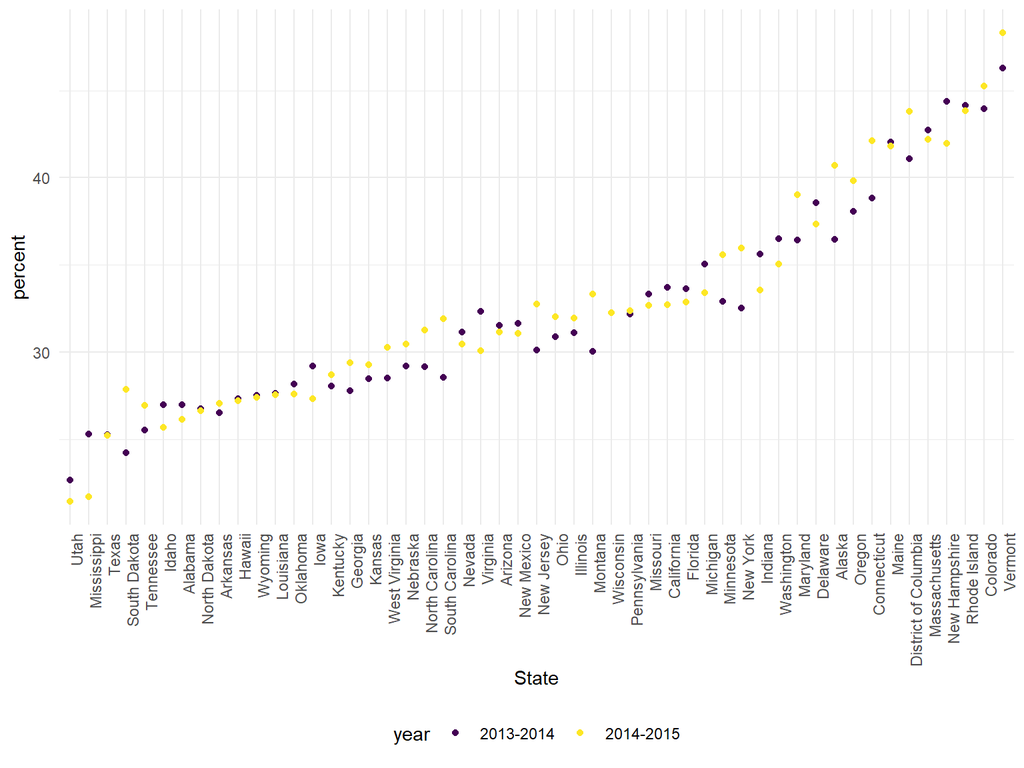

```r
marj_df |>
  filter(age == "18-25") |>
  mutate(State = fct_reorder(State, percent)) |>
  ggplot(aes(x = State, y = percent, color = year)) +
    geom_point() +
    theme(axis.text.x = element_text(angle = 90, hjust = 1))
```

## Restaurant inspections

read in the data. let’s understand this data a little more:

```r
data("rest_inspec")

rest_inspec |>
  count(boro, grade) |>
  pivot_wider(
    names_from = grade,
    values_from = n) |>
  knitr::kable()
```

| boro | A | B | C | Not Yet Graded | P | Z | NA |
| --- | --- | --- | --- | --- | --- | --- | --- |
| BRONX | 13688 | 2801 | 701 | 200 | 163 | 351 | 16833 |
| BROOKLYN | 37449 | 6651 | 1684 | 702 | 416 | 977 | 51930 |
| MANHATTAN | 61608 | 10532 | 2689 | 765 | 508 | 1237 | 80615 |
| Missing | 4 | NA | NA | NA | NA | NA | 13 |
| QUEENS | 35952 | 6492 | 1593 | 604 | 331 | 913 | 45816 |
| STATEN ISLAND | 5215 | 933 | 207 | 85 | 47 | 149 | 6730 |

OR

```r
rest_inspec |>
  group_by(boro, grade) |>
  summarize(n = n()) |>
  pivot_wider(names_from = grade, values_from = n)
```

```
## # A tibble: 6 × 8
## # Groups:   boro [6]
##   boro              A     B     C `Not Yet Graded`     P     Z  `NA`
##   <chr>         <int> <int> <int>            <int> <int> <int> <int>
## 1 BRONX         13688  2801   701              200   163   351 16833
## 2 BROOKLYN      37449  6651  1684              702   416   977 51930
## 3 MANHATTAN     61608 10532  2689              765   508  1237 80615
## 4 Missing           4    NA    NA               NA    NA    NA    13
## 5 QUEENS        35952  6492  1593              604   331   913 45816
## 6 STATEN ISLAND  5215   933   207               85    47   149  6730
```

now let’s get a better understanding:

```r
inspection_df =
  rest_inspec |>
  filter(grade %in% c("A", "B", "C"), boro != "Missing") |>
  mutate(boro = str_to_title(boro))

inspection_df
```

```
## # A tibble: 188,195 × 18
##    action          boro  building  camis critical_flag cuisine_description dba
##    <chr>           <chr> <chr>     <int> <chr>         <chr>               <chr>
##  1 Violations wer… Manh… 1271     5.00e7 Critical      American            THE …
##  2 Violations wer… Manh… 37       4.12e7 Not Critical  Korean              SHIL…
##  3 Violations wer… Manh… 53       4.04e7 Not Critical  Korean              HAN …
##  4 Violations wer… Manh… 287      4.16e7 Not Critical  American            BRGR
##  5 Violations wer… Manh… 800      4.11e7 Not Critical  Pizza               WALD…
##  6 Violations wer… Manh… 121      5.00e7 Not Critical  CafÃ©/Coffee/Tea    LUNA
##  7 Violations wer… Manh… 124      4.10e7 Critical      American            JOHN…
##  8 Violations wer… Manh… 138      4.11e7 Critical      American            AROM…
##  9 Violations wer… Manh… 839      5.00e7 Not Critical  American            L'AM…
## 10 Violations wer… Manh… 35       4.13e7 Critical      Korean              MADA…
## # ℹ 188,185 more rows
## # ℹ 11 more variables: inspection_date <dttm>, inspection_type <chr>,
## #   phone <chr>, record_date <dttm>, score <int>, street <chr>,
## #   violation_code <chr>, violation_description <chr>, zipcode <int>,
## #   grade <chr>, grade_date <dttm>
```

let’s look at the restaurant grades for some pizza restaurants:

```r
inspection_df |>
  filter(str_detect(dba, "Pizza")) |>
  count(boro)
```

```
## # A tibble: 5 × 2
##   boro              n
##   <chr>         <int>
## 1 Bronx            12
## 2 Brooklyn          6
## 3 Manhattan        34
## 4 Queens           17
## 5 Staten Island     5
```

(use `inspection_df |> slice(1:50) |> view())` in the console to view a select portion of this dataset to load faster)

```r
inspection_df =
  rest_inspec |>
  filter(grade %in% c("A", "B", "C"), boro != "Missing") |>
  mutate(
    boro = str_to_title(boro),
    dba = str_to_upper(dba))

inspection_df |>
  filter(str_detect(dba, "PIZZA")) |>
  count(boro)
```

```
## # A tibble: 5 × 2
##   boro              n
##   <chr>         <int>
## 1 Bronx          1531
## 2 Brooklyn       2305
## 3 Manhattan      2479
## 4 Queens         1954
## 5 Staten Island   471
```

^ see what we’re looking for in the dataset, make all of the lowercase values in `dba` uppercase so that we can find all the restaurants. there’s still probably double counting but it’s better than undercounting (from the previous code chunk).

[figure not shown]

```r
inspection_df |>
  filter(str_detect(dba, "PIZZA")) |>
  ggplot(aes(x = boro, fill = grade))
```